# DecisionTreeProgram

Mohammad Tariq

May 21, 2018

## R Markdown

R use **party** package to create decision trees. And in party package there is inbuilt dataset named as **readingSkills** on which we will create decision tree. we can get to know about datasets present in a particular package by executing the following R code

```r
  data(package='party')
```

The **party** package has the function called as **ctree** to create and analyzed tree. The dataset **readingSkills** has the attributes age,score,shoeSize and the Class varibale nativeSpeaker. Decision tree will describe that whether a person is a ntiveSpeaker or not by analyzing age,score and shoesize attributes.

## Input data readingSkills

The following data is the sample of readingSkills dataset

| nativeSpeaker | age | shoeSize | score |
| --- | --- | --- | --- |
| yes | 5 | 24.83189 | 32.29385 |
| yes | 6 | 25.95238 | 36.63105 |
| no | 11 | 30.42170 | 49.60593 |
| yes | 7 | 28.66450 | 40.28456 |
| yes | 11 | 31.88207 | 55.46085 |
| yes | 10 | 30.07843 | 52.83124 |
| no | 7 | 27.25963 | 34.40229 |
| yes | 11 | 30.72398 | 55.52747 |
| yes | 5 | 25.64411 | 32.49935 |
| no | 7 | 26.69835 | 33.93269 |
| yes | 11 | 31.86645 | 55.46876 |
| yes | 10 | 29.15575 | 51.34140 |
| no | 9 | 29.13156 | 41.77098 |
| no | 6 | 26.86513 | 30.03304 |
| no | 5 | 24.23420 | 25.62268 |
| yes | 6 | 25.67538 | 35.30042 |
| no | 5 | 24.86357 | 25.62843 |
| no | 6 | 26.15357 | 30.76591 |
| no | 9 | 27.82057 | 41.93846 |
| yes | 5 | 24.86766 | 31.69986 |

```r
training.Data<-readingSkills[c(1:110), ]
```

Now we will create decision tree using **ctree()** function.

```r
decision.tree<- ctree(
  nativeSpeaker ~ age + shoeSize + score, data = training.Data
)
```

## Decision Tree

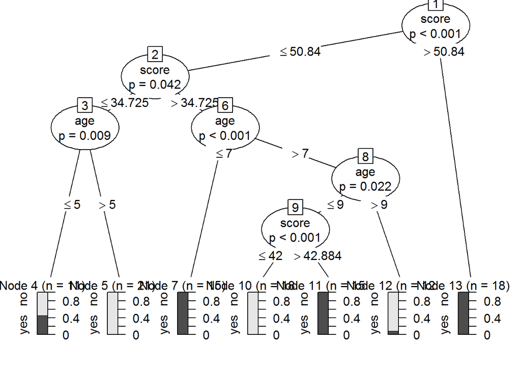

```r
plot(decision.tree)
```

## Conclusion

From above tree we can conclude that

- A person whose readingSkills Score is greater than 50.84 is a nativeSpeaker.
- A person whose score is greater than 34.72 and age is less than or equal to 7 is also a nativeSpeaker.